# DADA2 pipeline

Copyright (c) 2018 Service de Pneumologie, Centre Hospitalier Universitaire Vaudois (CHUV), Switzerland

Converting amplicons nucleotides sequences from FASTQ files to a table of Amplicons Sequences Variants (ASV) using the DADA2 pipeline (R package {dada2}).

The full documentation on required files and preparation is available in the README.md file and at https://github.com/chuvpne/dada2-pipeline.

# Project Information

Analysis author: A. Robot

Investigators: J. A. Zoidberg

Date: 2053.01.10

Project: ABC01

#### Sequencing Details

Run ID: run01

Type: bacterial 16S rRNA gene amplicons v1-v2/F27-R338

Platform: Illumina MiSeq PE v2 2x250

Date: 2053.01.01

Place: Lambda sequencing facility

# Demultiplexing

Demultiplexing is performed using the `iu-demultiplex` command from the illumina-utils FASTQ files processing toolbox. If multiple runs have to be processed, this will be done in parallel. The `-j` argument in the `parallel` command specifies the number of computing cores to use. You may edit it to your need (considering both available CPUs and memory).

```r
# BASH
# For each run, store demultiplexed sequences in a new directory named "demultiplexed"
ls -d run_data/* \
  | parallel -j -2 'outputdir=demultiplexed; [[ ! -d {}/"${outputdir}" ]] && mkdir {}/"${outputdir}"; gunzip {}/*.fastq.gz && iu-demultiplex -s {}/barcode_to_sample.txt --r1 {}/R1.fastq --r2 {}/R2.fastq -i {}/Index.fastq -x -o {}/"${outputdir}"'
```

# Running the DADA2 pipeline

## Environment setup

Packrat will install packages listed in the packrat.lock file from sources found in the `packrat/src` directory into the `packrat/lib` directory. This takes a while but will not repeat after first installation.

Distribution of computation over multiple computing cores (parallelization) will be handled by the `doParallel` package.

```r
# R
# Install required R librairies with packrat
packrat::set_opts(use.cache=FALSE)
packrat::restore()
.libPaths(file.path("packrat", list.files("packrat", pattern = "lib"), "x86_64-pc-linux-gnu", "3.5.1"))
```

```
[1] \R version 3.5.1 (2018-07-02)\
```

`r`r version$platform

```
[1] \x86_64-pc-linux-gnu\
```

```
[1] ‘1.10.0’
```

```
[1] ‘1.4.4’
```

```
[1] ‘1.0.14’
```

```
[1] ‘3.1.0’
```

```
[1] ‘0.2’
```

```
[1] ‘1.4.3’
```

```
[1] ‘1.11.8’
```

```
[1] \10 cores used\
```

## Quality Check

The DADA2 `plotQualityProfile` function plots a visual summary of the distribution of quality scores as a function of sequence position for the input fastq file.

This can take minutes to hours.

```r
# R
runs.dirs <- list.dirs("run_data", recursive = F)
runs <- basename(runs.dirs)

plots <- foreach(i=1:length(runs), .packages = c("dada2", "ggplot2")) %dopar% {
  p <- list()
  p[[1]] <- plotQualityProfile(file.path(runs.dirs[i], "R1.fastq"), n = 1e+06) +
    ggtitle(paste("Forward reads |", runs[i], sep=" "))
  p[[2]] <- plotQualityProfile(file.path(runs.dirs[i], "R2.fastq"), n = 1e+06) +
    ggtitle(paste("Reverse reads |", runs[i], sep=" "))
  p
}

# Store the quality profile in the run directory
for (i in 1:length(runs)) {
  saveRDS(plots[[i]], file.path(runs.dirs[i], "quality_score.pdf.rds"))
  pdf(file.path(runs.dirs[i], "quality_score.pdf"))
  invisible(lapply(plots[[i]], print))
  invisible(dev.off())
}
```

Combine quality profiles of all runs in a condensed summary.

`r`r

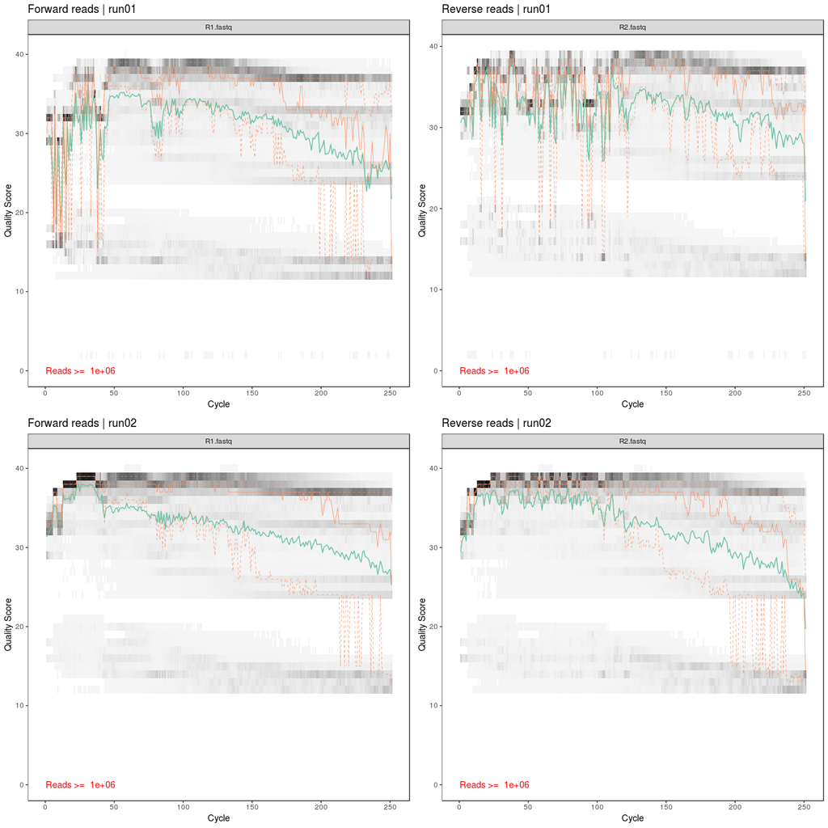

```r
# R
nplot.pp <- 4  # number of plots per page
ncol.pp <- 2  # number of columns in a page
fig <- foreach(i=seq(1, length(unlist(plots, recursive = F)), by=nplot.pp), .packages = c(\ggpubr\)) %dopar% {
  ggarrange(plotlist=unlist(plots, recursive = F)[i:(i+nplot.pp-1)], ncol=ncol.pp, nrow=nplot.pp/ncol.pp)
}
invisible(lapply(fig, print))
```

```r
# R
# Store the quality profile summary in fig/quality_score.pdf
dir.create("fig")
pdf("fig/quality_score.pdf", paper="a4")
  invisible(lapply(fig, print))
invisible(dev.off())
```

## Quality Filtering & Trimming

The DADA2 `filterAndTrim` function trims sequences to a specified length, removes sequences shorter than that length, and filters based on the number of ambiguous bases, a minimum quality score, and the expected errors in a read. Based on the quality profiles, adjust the trimming (for each run). Your reads must still overlap after truncation in order to merge them later (basic rule is truncLen must be large enough to maintain 20 + biological.length.variation nucleotides of overlap between them).

```r
# R
# For each run, store the filtered sequences in a new directory named "filtered"
filterAndTrim.out <- vector("list", length(runs))
for(i in 1:length(runs)) {
  fwd.fn <- sort(list.files(file.path(runs.dirs[i], "demultiplexed"), pattern = '-R1.fastq'))
  rev.fn <- sort(list.files(file.path(runs.dirs[i], "demultiplexed"), pattern = '-R2.fastq'))
  filterAndTrim.out[[i]] <- filterAndTrim(fwd=file.path(runs.dirs[i], "demultiplexed", fwd.fn),
                filt=file.path(runs.dirs[i], "filtered", fwd.fn),
                rev=file.path(runs.dirs[i], "demultiplexed", rev.fn),
                filt.rev=file.path(runs.dirs[i], "filtered", rev.fn),
                truncLen=c(240, 200),
                maxEE=c(5, 7),
                truncQ=0,
                maxN=0,
                rm.phix=TRUE,
                compress=TRUE,
                verbose=TRUE,
                multithread=nc)
}

# Store the filtering report in the run directory
filt.plots <- foreach(i=1:length(runs), .packages = c("ggplot2", "reshape2")) %do% {
  saveRDS(filterAndTrim.out[[i]], file.path(runs.dirs[i], "filtering_report.rds"))
  data <- as.data.frame(filterAndTrim.out[[i]])
  row.names(data) <- gsub("-R1.fastq", "", row.names(data))
  data$reads.in <- data$reads.in - data$reads.out
  p <- ggplot(melt(as.matrix(data)), aes(x=Var1, y=value, fill=Var2)) +
    geom_bar(stat="identity") +
    theme(axis.text.x = element_text(angle = 90, hjust = 1, vjust = 0.5)) +
    labs(title = runs[i], x = "Samples", y = "Reads", fill = NULL)
  saveRDS(p, file.path(runs.dirs[i], "filtering_report.pdf.rds"))
  pdf(file.path(runs.dirs[i], "filtering_report.pdf"))
  print(p)
  invisible(dev.off())
  p
}
pdf("fig/filtering_report.pdf")
invisible(lapply(filt.plots, print))
invisible(dev.off())
```

`r`r

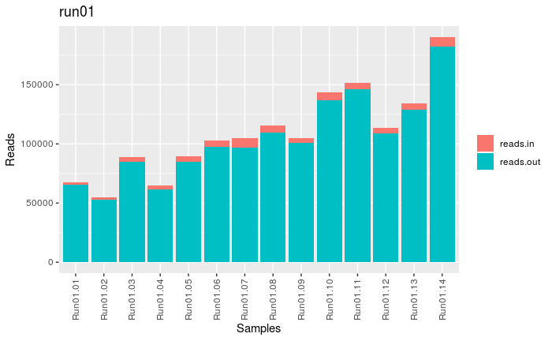

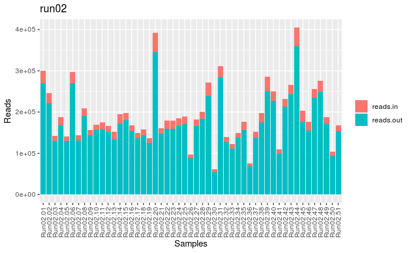

```r
# R
invisible(lapply(filt.plots, print))
```

## Sequencing Error Model Generation

The DADA2 algorithm makes use of a parametric error model err and every amplicon dataset has a different set of error rates. The learnErrors method learns this error model from the data, by alternating estimation of the error rates and inference of sample composition until they converge on a jointly consistent solution.

```r
# R
err.model <- foreach(i = 1:length(runs), .packages = c("dada2", "ggplot2")) %dopar% {
  fwd.fn <- sort(list.files(file.path(runs.dirs[i], "filtered"), pattern = '-R1.fastq'))
  rev.fn <- sort(list.files(file.path(runs.dirs[i], "filtered"), pattern = '-R2.fastq'))
  err <- list()
  err[[1]] <- learnErrors(file.path(runs.dirs[i], "filtered", fwd.fn), nbases=1e8, multithread=nc)
  err[[2]] <- learnErrors(file.path(runs.dirs[i], "filtered", rev.fn), nbases=1e8, multithread=nc)
  err
}
# Plot the error model
err.plots <- foreach(i = 1:length(runs), .packages = c("dada2", "ggplot2")) %do% {
  p <- list()
  p[[1]] <- plotErrors(err.model[[i]][[1]], nominalQ=TRUE) +
                   ggtitle(paste(runs[i], "| forward reads"))
  p[[2]] <- plotErrors(err.model[[i]][[2]], nominalQ=TRUE) +
                   ggtitle(paste(runs[i], "| reverse reads"))
  p
}

# Store the error model in the run directory
for (i in 1:length(runs)) {
  saveRDS(err.model[[i]], file.path(runs.dirs[i], "error_model.rds"))
  saveRDS(err.plots[[i]], file.path(runs.dirs[i], "error_model.pdf.rds"))
  pdf(file.path(runs.dirs[i], "error_model.pdf"))
  invisible(lapply(err.plots[[i]], print))
  invisible(dev.off())
}
```

Combine error models of all runs in a condensed summary.

`r`r

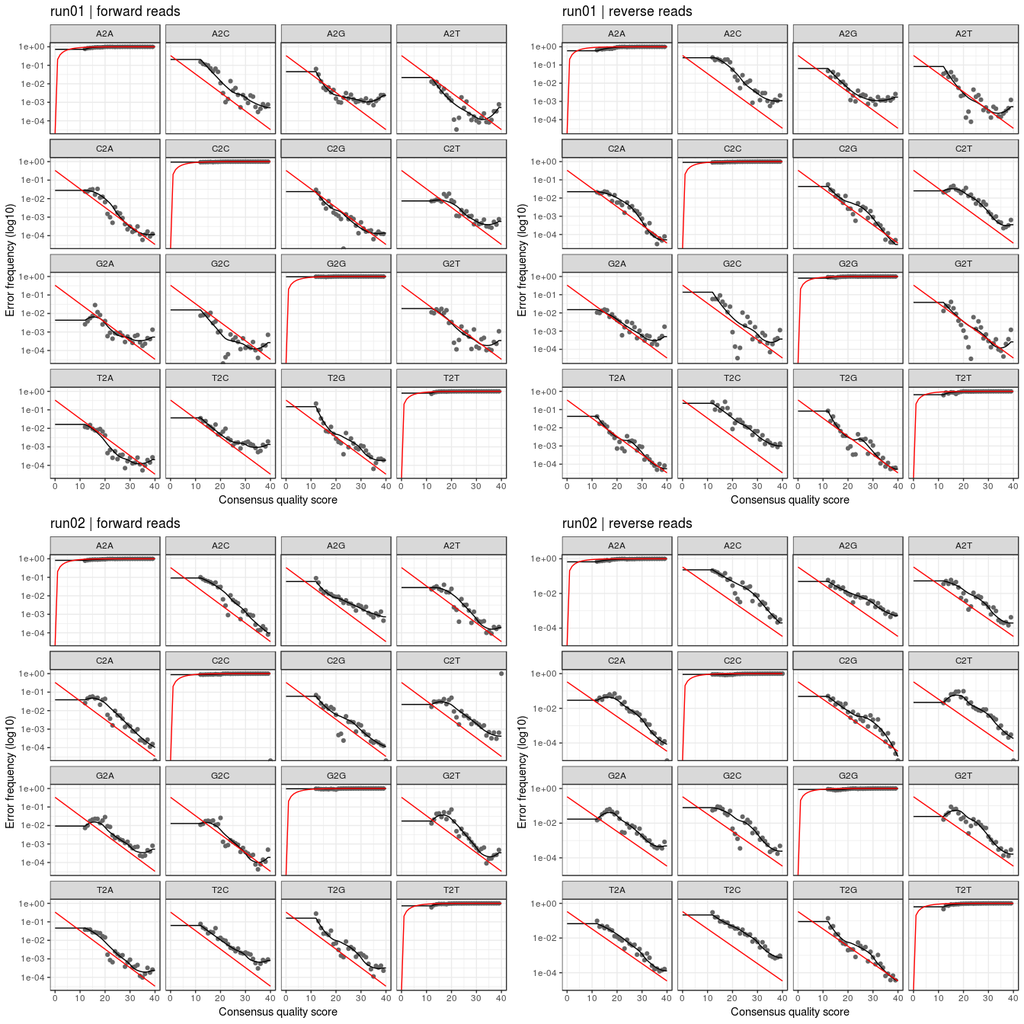

```r
# R
nplot.pp <- 4  # number of plots per page
ncol.pp <- 2  # number of columns in a page
fig <- foreach(i=seq(1, length(unlist(err.plots, recursive = F)), by=nplot.pp), .packages = c(\ggpubr\)) %dopar% {
  ggarrange(plotlist=unlist(err.plots, recursive = F)[i:(i+nplot.pp-1)], ncol=ncol.pp, nrow=nplot.pp/ncol.pp)
}
invisible(lapply(fig, print))
```

Transitions (A→C, A→G, …) are shown. Points are the observed error rates for each consensus quality score. The black line shows the estimated error rates after convergence of the machine-learning algorithm. The red line shows the error rates expected under the nominal definition of the Q-score. Here the estimated error rates (black line) are a good fit to the observed rates (points), and the error rates drop with increased quality as expected.

```r
# R
# Store the error model summary in fig/error_model.pdf
pdf("fig/error_model.pdf", paper="a4")
  invisible(lapply(fig, print))
invisible(dev.off())
```

## Count Table Generation

A table with amplicon sequence variants is constructed. To avoid overloading memory, runs and samples are processed sequentialy.

The process starts with sequences dereplication, then it goes through Amplicon Sequence Variants (ASVs) inference and ends with Paired-Ends (PE) merging. These steps are detailed below.

### Sequences Dereplication

Dereplication combines all identical sequencing reads into into “unique sequences” with a corresponding “abundance” equal to the number of reads with that unique sequence. Dereplication in the DADA2 pipeline has one crucial addition from other pipelines: DADA2 retains a summary of the quality information associated with each unique sequence. The consensus quality profile of a unique sequence is the average of the positional qualities from the dereplicated reads. The consensus scores are then used by the error model of the dada function.

### Amplicon Sequence Variants (ASVs) Inference

The core method of the DADA2 package is at the sample inference stage (the dada function). It will assign all reads to an error-corrected sequence using the models of the error rates of the previous step.

### Paired-Ends (PE) Merging

This step performs a global ends-free alignment between paired forward and reverse reads and merges them together if they exactly overlap. It requires that the input forward and reverse reads are in the same order. Note that merging in the DADA2 pipeline happens after denoising, hence the strict requirement of exact overlap since it is expected that nearly all substitution errors have already been removed.

```r
# R
for(i in 1:length(runs)) {

  fwd.fn <- sort(list.files(file.path(runs.dirs[i], "filtered"), pattern = "-R1.fastq"))
  rev.fn <- sort(list.files(file.path(runs.dirs[i], "filtered"), pattern = "-R2.fastq"))
  sample.names <- sapply(strsplit(basename(fwd.fn), "-R1.fastq"), `[`, 1)
  sample.names.rev <- sapply(strsplit(basename(rev.fn), "-R2.fastq"), `[`, 1)
  if (!identical(sample.names, sample.names.rev)) stop("Forward and reverse files do not match.")
  names(fwd.fn) <- sample.names
  names(rev.fn) <- sample.names

  merged <- vector("list", length(sample.names))
  names(merged) <- sample.names
  for(j in 1:length(sample.names)) {
    derep <- vector("list", 2)
    derep[[1]] <- derepFastq(file.path(runs.dirs[i], "filtered", fwd.fn[j]))
    derep[[2]] <- derepFastq(file.path(runs.dirs[i], "filtered", rev.fn[j]))
    asv <- vector("list", 2)
    asv[[1]] <- dada(derep[[1]], err=err.model[[i]][[1]], pool = TRUE, multithread=nc)
    asv[[2]] <- dada(derep[[2]], err=err.model[[i]][[2]], pool = TRUE, multithread=nc)
    merged[[sample.names[j]]] <- mergePairs(asv[[1]], derep[[1]], asv[[2]], derep[[2]])
  }

  st <- makeSequenceTable(merged)
  saveRDS(st, file.path(runs.dirs[i], "seqtab.rds"))
}
```

## Merging Runs

```r
# R
seqtab.fps <- file.path(runs.dirs, "seqtab.rds")
if (length(seqtab.fps) == 1) {
  seqtab <- readRDS(seqtab.fps[[1]])
} else {
  seqtab <- mergeSequenceTables(tables = seqtab.fps)
}

# Save data into a new directory named "data"
dir.create("data")
saveRDS(seqtab, "data/seqtab.rds")
```

## Chimera Screening

The dada algorithm models and removes substitution errors, but chimeras are another importance source of spurious sequences in amplicon sequencing. Chimeras are formed during PCR amplification. When one sequence is incompletely amplified, the incomplete amplicon primes the next amplification step, yielding a spurious amplicon. The result is a sequence read which is half of one sample sequence and half another.

```r
# R
seqtab.nochim <- removeBimeraDenovo(seqtab, method="consensus", multithread=nc, verbose = T)
saveRDS(seqtab.nochim, "data/seqtab_nochim.rds")
fwrite(as.data.frame(seqtab.nochim), "data/seqtab_nochim.txt", quote = F, sep = "\t")

# Inspect distribution of sequence lengths after chimera removal
distrib <- table(nchar(getSequences(seqtab.nochim)))
distrib.plot <- function(){
  plot(distrib, xlab = 'Read length', ylab = 'Number of ASVs')
}
saveRDS(distrib, "data/length_distribution.rds")
pdf("fig/length_distribution.pdf")
distrib.plot()
invisible(dev.off())
```

`r`r # R # Check the dimensions of the table before chimera removal dim(seqtab)

```
[1]   65 7070
```

`r`r # Check the dimensions of the table after chimera removal dim(seqtab.nochim)

```
[1]   65 4728
```

`r`r distrib.plot()

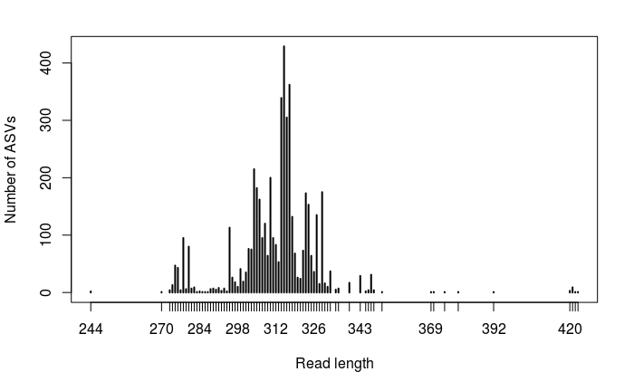

### Reads Tracking

As a final check of our progress, we look at the number of reads that made it through each step in the pipeline. Outside of filtering (first step) there should be no step in which a majority of reads are lost. If a majority of reads failed to merge, you may need to revisit the truncLen parameter used in the filtering step and make sure that the truncated reads span your amplicon. If a majority of reads were removed as chimeric, you may need to revisit the removal of primers, as the ambiguous nucleotides in unremoved primers interfere with chimera identification.

```r
# R
track.plots <- foreach(i=1:length(runs), .packages = c("ggplot2", "reshape2")) %do% {
  filtering <- readRDS(file.path(runs.dirs[i], "filtering_report.rds"))
  row.names(filtering) <- gsub("-R1.fastq", "", row.names(filtering))
  track <- cbind(filtering,
                 rowSums(seqtab[row.names(filtering), ]),
                 rowSums(seqtab.nochim[row.names(filtering), ]))
  colnames(track) <- c("Input", "Filtered", "Merged", "Non chimeric")
  for (j in (ncol(track)-1):1) {
    for (k in (j+1):ncol(track)) {
      track[, j] <- track[, j] - track[, k]
    }
  }
  p <- ggplot(melt(as.matrix(track)), aes(x=Var1, y=value, fill=Var2)) +
    geom_bar(stat="identity") +
    theme(axis.text.x = element_text(angle = 90, hjust = 1, vjust = 0.5)) +
    labs(title = runs[i], x = "Samples", y = "Reads", fill = NULL)
  saveRDS(p, file.path(runs.dirs[i], "read_tracking_report.pdf.rds"))
  pdf(file.path(runs.dirs[i], "read_tracking_report.pdf"))
  print(p)
  invisible(dev.off())
  p
}
pdf("fig/read_tracking_report.pdf")
invisible(lapply(track.plots, print))
invisible(dev.off())
```

`r`r # R invisible(lapply(track.plots, print))

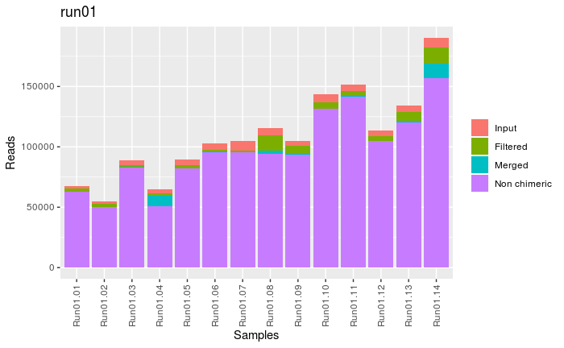

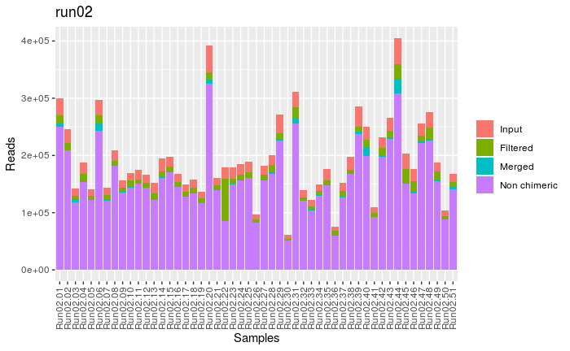

## Taxonomy Assignment

The DADA2 package provides a native implementation of the naive Bayesian classifier method for this purpose. The assignTaxonomy function takes as input a set of sequences to be classified and a training set of reference sequences with known taxonomy, and outputs taxonomic assignments with at least minBoot bootstrap confidence.

```r
# R

# Path to the DADA2-formatted reference database
# Note: use -v to mount the database when using docker containers
# Replace "/path/to/train_set.fa.gz" by the right path to the reference database (ex:"/home/user/db/silva_nr_v132_train_set.fa.gz")
db.fp <- "/path/to/train_set.fa.gz"

taxonomy <- assignTaxonomy(seqtab.nochim, db.fp, minBoot = 100, multithread=nc)
saveRDS(taxonomy, "data/taxonomy.rds")
fwrite(as.data.frame(taxonomy), "data/taxonomy.txt", quote = F, sep = "\t")
```

The DADA2 package also implements a method to make species level assignments based on exact matching between ASVs and sequenced reference strains. Recent analysis suggests that exact matching (or 100% identity) is the only appropriate way to assign species to 16S gene fragments. Currently, species-assignment training fastas are available for the SILVA and RDP 16S databases.

```r
# R

# Path to the DADA2-formatted reference database for species assignment
# Note: use -v to mount the database when using docker containers
# Replace "/path/to/species_assignment.fa.gz" by the right path to the reference database for species assignment (ex:"/home/user/db/silva_species_assignment_v132.fa.gz")
db.fp <- "/path/to/species_assignment.fa.gz"

taxonomy.species <- addSpecies(taxonomy, db.fp)
saveRDS(taxonomy.species, "data/taxonomy_species.rds")
fwrite(as.data.frame(taxonomy.species), "data/taxonomy_species.txt", quote = F, sep = "\t")
```

## Export in Qiime classic OTU table-like format

The DADA2 pipeline provides results as a count table of ASVs per samples and a taxonomic classification of each ASV in two separate files. As detailed in the DADA2 tutorial (https://benjjneb.github.io/dada2/tutorial.html), these two objects can easily be used with the phyloseq R package for subsequent data analysis.

For compatibility with other data analysis tools, a count table in a tab-delimited text format matching the Qiime classic OTU table format (https://www.drive5.com/usearch/manual/qiime_classic.html) is also created. The table contains samples in columns and ASVs in rows. The taxonomy at the species level is added as an extra “taxonomy” column. The first columns contains mock OTU IDs.

```r
# R
dada2otu <- function(seqtab=NULL, taxonomy=NULL) {
  out <- as.data.frame(cbind(c(1:nrow(taxonomy)), t(as.data.frame(seqtab)), apply(as.data.frame(taxonomy), 1, paste, collapse = "; ")))
  row.names(out) <- c(1:nrow(out))
  names(out) <- c("#OTU ID", row.names(as.data.frame(seqtab)), "taxonomy")
  return(out)
}
fwrite(dada2otu(seqtab.nochim, taxonomy.species), "data/otu_table.txt", quote = F, sep = "\t")
```

## Wrapping Up

Compile all barcode_to_sample.txt files into a single mapping file stored in the `data` directory.

Archive the initial, multiplexed fastq files along with the `barcode_to_sample.txt` files and run-specific figures and intermediate files in an archive named `run_data.tar.gz`.

Finaly, create a html report and archive it along with final data, figures, packrat .lock and package sources as well as this R Notebook. Intermediate files and compiled R libraries will be ignored.

```r
# BASH
# Create a global mapping file
[[ -e "data/map.txt" ]] && rm "data/map.txt"
ls -d run_data/* \
  | parallel -j -2 'sed -e "s|$| \t"{/}"|g" {}/barcode_to_sample.txt >> data/map.txt'
```

```r
# BASH
# Archive the multiplexed fastq files
ls -d run_data/* \
  | parallel -j -2 'gzip {}/*.fastq'
[[ ! -d run_data_archives ]] && mkdir run_data_archives
ls run_data/* -d \
  | parallel -j -2 'cd {} && tar zcvmf ../../run_data_archives/{/}.tar.gz --exclude=*demultiplexed* --exclude=*filtered* *'
```

```r
# R
# Create a html report
rmarkdown::render("example.Rmd")
```

```r
# BASH
# Archive the results
zip -r dada2-pipeline.zip --exclude=packrat/lib* data fig packrat example.Rmd dada2-pipeline.Rproj example.nb.html README.md LICENSE.txt
```